# [Tutorial] TCGA

## 3.3 Tumor stages of lung cancers

First information you might want to explore is staging cancers. Different types of staging systems are used for different types of cancer. You can read further information in general staging rules, or specifics in lung cancers (e.g. stage IA).

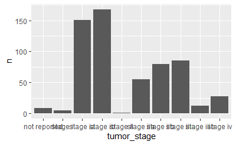

```r
# Count the number of tumors in the LUAD dataset
counts_tumor <- d_luad %>% dplyr::count(tumor_stage)

# Try bar plot
ggplot(counts_tumor, aes( tumor_stage, n)) + geom_bar(stat="identity")
```

Now you can combine both for visualization.

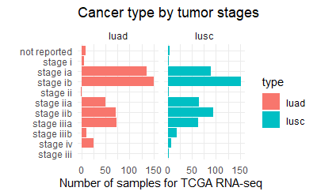

```r
# Cancer type by tumor stages
bind_rows(d_luad %>%
            filter(shortLetterCode == 'TP') %>%
            mutate(type='luad') %>%
            select(type, tumor_stage),
          d_lusc %>%
            filter(shortLetterCode == 'TP') %>%
            mutate(type='lusc') %>%
            select(type, tumor_stage)) %>%
  dplyr::count(type, tumor_stage) %>%
  mutate(tumor_stage = factor(tumor_stage, levels=rev(unique(tumor_stage)))) %>%
  ggplot(aes( tumor_stage, n, fill=type)) +
  labs(title = 'Cancer type by tumor stages',
       x = '', y='Number of samples for TCGA RNA-seq') +
  theme_minimal() + geom_bar(stat="identity") +
  facet_wrap(~type) + coord_flip()
```

## 3.4 Cancer type by gender

Let’s try another information - gender. We will describe this by a bar plot like above. After plotting, which information you can read from this? NB: I am not pretty sure why TCGA put gender, not sex in the dataset, in addition to mixed use of female/male with gender.

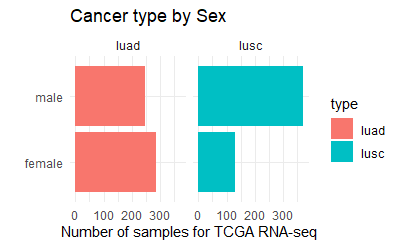

```r
# Cancer type by Sex
bind_rows(d_luad %>%
            filter(shortLetterCode == 'TP') %>%
            mutate(type='luad') %>%
            select(type, gender),
          d_lusc %>%
            filter(shortLetterCode == 'TP') %>%
            mutate(type='lusc') %>%
            select(type, gender)) %>%
  dplyr::count(type, gender) %>%
  ggplot(aes( gender, n, fill=type)) +
  labs(title = 'Cancer type by Sex',
       x = '', y='Number of samples for TCGA RNA-seq') +
  theme_minimal() + geom_bar(stat="identity") +
  facet_wrap(~type) + coord_flip()
```

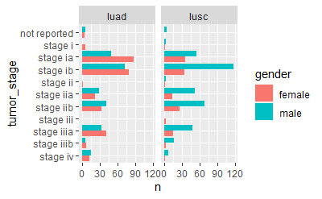

```r
# Add gender with stages
bind_rows(d_luad %>%
            filter(shortLetterCode == 'TP') %>%
            mutate(type='luad') %>%
            select(type, tumor_stage, gender),
          d_lusc %>%
            filter(shortLetterCode == 'TP') %>%
            mutate(type='lusc') %>%
            select(type, tumor_stage, gender)) %>%
  dplyr::count(type, tumor_stage, gender) %>%
  complete(gender, type, tumor_stage, fill = list(n = 0)) %>%
  mutate(tumor_stage = factor(tumor_stage, levels=rev(unique(tumor_stage))),
         gender = factor(gender)) %>%
  ggplot(., aes(tumor_stage, n, fill=gender)) +
  geom_bar(stat="identity", position=position_dodge()) +
  facet_wrap(~type) + coord_flip()
```

## 3.5 Site of biopsy

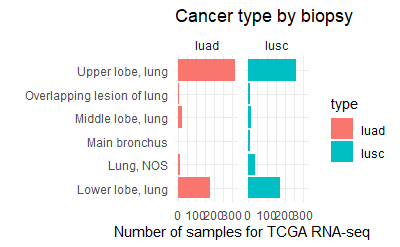

```r
# Cancer type by biopsy
bind_rows(d_luad %>%
            filter(shortLetterCode == 'TP') %>%
            mutate(type='luad') %>%
            select(type, site_of_resection_or_biopsy),
          d_lusc %>%
            filter(shortLetterCode == 'TP') %>%
            mutate(type='lusc') %>%
            select(type, site_of_resection_or_biopsy)) %>%
  dplyr::count(type, site_of_resection_or_biopsy) %>%
  ggplot(aes( site_of_resection_or_biopsy, n, fill=type)) +
  labs(title = 'Cancer type by biopsy',
       x = '', y='Number of samples for TCGA RNA-seq') +
  theme_minimal() + geom_bar(stat="identity") +
  facet_wrap(~type) + coord_flip()
```

Plot the years at diagnosis by tissue or organ of origin. We would also include difference by gender.

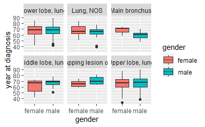

```r
bind_rows(d_luad %>%
            filter(shortLetterCode == 'TP') %>%
            mutate(type='luad') %>%
            select(type, gender, age_at_diagnosis, tissue_or_organ_of_origin),
          d_lusc %>%
            filter(shortLetterCode == 'TP') %>%
            mutate(type='lusc') %>%
            select(type, gender, age_at_diagnosis, tissue_or_organ_of_origin)) %>%
  ggplot(., aes(gender, age_at_diagnosis/365, fill=gender)) +
  geom_boxplot() + labs(y='year at diagnosis') +
  facet_wrap(~tissue_or_organ_of_origin)
```